# An Analysis on New York City's Famous Yellow Cabs

By: **Jared Habermehl** (I will be refering to myself as "we" instead of "me" to keep on par with other groups)

## Introduction

Throughout most of modern history in New York City, the yellow taxis that frequent the streets have become a staple of New York City itself. Known for being omnipresent, ever useful, and seemingly necessary, its presence in recent years seems to have not been reconsidered due to the taxi's historical significance. However, with the advent of competing private companies such as Lyft and Uber, who provide similar services at fractions of a charge, do taxis still provide the same usefulness they once did, 30, 20, even 10 years ago?

Throughout this tutorial, we will investigate how passengers are using taxis in the modern era and see if New York City is still making any profit off of taxis anymore due to the large amount of competiton.

## What we need before we get started

The Python libraries that will be used throughout this tutorial include

- Pandas
- Numpy
- MatplotLib
- Pyarrow
- FastParquet
- GeoPy

### Data Collection

All the data that is used during this research was found on [New York City's data page on the topic](https://www1.nyc.gov/site/tlc/about/tlc-trip-record-data.page). Extra processing will be done on the data to help extract exactly what we want. We chose this research to focus on the **first 500,000 fares of January, 2018** since taking even a week or the full month is way too many entries (~8.7 million entries) and we wanted to focus on pre-pandemic rates as well as passenger frequency. Since we know the number of fares in total in January we can extrapolate the first 500,0000 to the full month.

```python
import pandas as pd
import numpy as np
import matplotlib.pyplot as matplt
from geopy import geocoders

# Required to init geocoders properly
gn = geocoders.GeoNames(username="JHabz")
```

```python
df = pd.read_parquet("yellow_tripdata_2018-01.parquet")
lookup_table = pd.read_csv("taxi_zone_lookup.csv")

# As discussed, only first 500000 entries
df = df.iloc[:500000,:]

df.head()
```

|  | VendorID | tpep_pickup_datetime | tpep_dropoff_datetime | passenger_count | trip_distance | RatecodeID | store_and_fwd_flag | PULocationID | DOLocationID | payment_type | fare_amount | extra | mta_tax | tip_amount | tolls_amount | improvement_surcharge | total_amount | congestion_surcharge | airport_fee |
| --- | --- | --- | --- | --- | --- | --- | --- | --- | --- | --- | --- | --- | --- | --- | --- | --- | --- | --- | --- |
| 0 | 1 | 2018-01-01 00:21:05 | 2018-01-01 00:24:23 | 1 | 0.5 | 1 | N | 41 | 24 | 2 | 4.5 | 0.5 | 0.5 | 0.00 | 0.0 | 0.3 | 5.80 | NaN | NaN |
| 1 | 1 | 2018-01-01 00:44:55 | 2018-01-01 01:03:05 | 1 | 2.7 | 1 | N | 239 | 140 | 2 | 14.0 | 0.5 | 0.5 | 0.00 | 0.0 | 0.3 | 15.30 | NaN | NaN |
| 2 | 1 | 2018-01-01 00:08:26 | 2018-01-01 00:14:21 | 2 | 0.8 | 1 | N | 262 | 141 | 1 | 6.0 | 0.5 | 0.5 | 1.00 | 0.0 | 0.3 | 8.30 | NaN | NaN |
| 3 | 1 | 2018-01-01 00:20:22 | 2018-01-01 00:52:51 | 1 | 10.2 | 1 | N | 140 | 257 | 2 | 33.5 | 0.5 | 0.5 | 0.00 | 0.0 | 0.3 | 34.80 | NaN | NaN |
| 4 | 1 | 2018-01-01 00:09:18 | 2018-01-01 00:27:06 | 2 | 2.5 | 1 | N | 246 | 239 | 1 | 12.5 | 0.5 | 0.5 | 2.75 | 0.0 | 0.3 | 16.55 | NaN | NaN |

```python
lookup_table.head()
```

|  | LocationID | Borough | Zone | service_zone |
| --- | --- | --- | --- | --- |
| 0 | 1 | EWR | Newark Airport | EWR |
| 1 | 2 | Queens | Jamaica Bay | Boro Zone |
| 2 | 3 | Bronx | Allerton/Pelham Gardens | Boro Zone |
| 3 | 4 | Manhattan | Alphabet City | Yellow Zone |
| 4 | 5 | Staten Island | Arden Heights | Boro Zone |

## Cleaning up the data set

Clearly, there are a lot of rows that are not helpful within the scope of this analysis. As it stands, New York City breaks up itself into "regions" with IDs (as shown in the PULOcationID column and DOLocationID column); getting the latitude and longitude of the pickup and drop off location IDs would be a lot more helpful for us than what they are currently using.

It is worth pointing out that the congestion surcharge and airport fee were not added until after January 2018 which means they are all empty, so it is safe to remove.

```python
df.drop(columns=["VendorID", "RatecodeID", "store_and_fwd_flag", "payment_type", "congestion_surcharge", "airport_fee"], inplace=True)
df["PickupZone"] = df.apply(lambda row: lookup_table.loc[lookup_table['LocationID'] == row.PULocationID, 'Zone'].iloc[0], axis=1)
df["DropoffZone"] = df.apply(lambda row: lookup_table.loc[lookup_table['LocationID'] == row.DOLocationID, 'Zone'].iloc[0], axis=1)
```

## Exploratory investigation into the total revenue from taxis

Thanks to the data being so nice, this is rather simple, only taking the sum of all the rows of the total_amount. However, we can take it a step further and see how tips, surcharges, and mta_tax play a role in the total income. Tolls are included since even though the taxi driver does not get the money, the city does receive this money anyway (since they control the tax income).

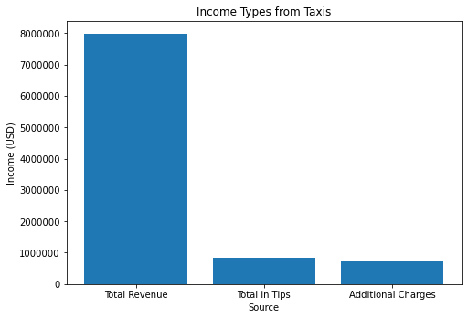

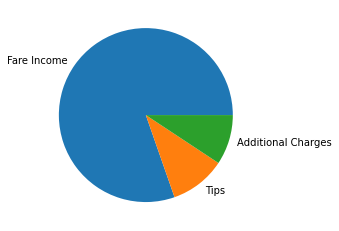

```python
total_revenue = df["total_amount"].sum()
total_tips = df["tip_amount"].sum()
extra_charges = df["extra"].sum() + df["mta_tax"].sum() + df["improvement_surcharge"].sum() + df["tolls_amount"].sum()

fig = matplt.figure()
ax = fig.add_axes([0,0,1,1])
x_names = ['Total Revenue', 'Total in Tips', 'Additional Charges']
money_values = [total_revenue, total_tips, extra_charges]
ax.bar(x_names,money_values)
ax.set_xlabel("Source")
ax.set_ylabel("Income (USD)")
ax.set_title("Income Types from Taxis")
matplt.gcf().axes[0].yaxis.get_major_formatter().set_scientific(False)
matplt.show()

no_tip_or_extra_revenue = total_revenue - total_tips - extra_charges
y = np.array([no_tip_or_extra_revenue, total_tips, extra_charges])

matplt.pie(y, labels = ["Fare Income", "Tips", "Additional Charges"])
matplt.show()
```

# Conclusions

Despite the recent adversity that New York Taxi drivers have faced in the wake of other services that provide similar if not better cost efficiency, the famous yellow taxis that still roam the streets of New York still provide an effective and lucrative means of transportation around the city. Clearly, with over 100 million rides each year, which is **over 12 times the entire New York City population combined**, yellow taxi cabs are still essential to the city that never sleeps.